# **Urban Parking Demand Forecasting Using Graph Neural Networks**

**Author:** Aishwarya Ravichandran  
**Project Team:** Chiranjeevi Veluri, Aditya, and Aishwarya Ravichandran  
**Technology Stack:** Python, Pandas, NetworkX, PyTorch, PyTorch Geometric, Matplotlib  
**Dataset:** Melbourne Parking Sensor Data  
**Objective:** Predict next time-step parking occupancy for selected Melbourne areas using Graph Neural Networks (GNNs).

## **Executive Summary**

This use case presents an intelligent urban parking demand forecasting system that predicts whether parking bays in Melbourne will be occupied or free at the next time step. The solution leverages Graph Neural Networks (GNNs) to capture both temporal patterns, such as hour of day and day of week, and spatial relationships between nearby parking bays.

Each parking bay is modeled as a node in a graph, while edges connect bays that are geographically close. By learning from these relationships, the model can forecast occupancy more effectively than traditional machine learning methods that treat parking bays independently.

To make the system practical and interactive, users can select a Melbourne area (e.g., Richmond or Docklands) and specify a desired hour and day. The trained model then predicts parking occupancy for all bays in the selected area and presents the results through an interactive visualization. Users can click on any parking bay to inspect detailed information, including Bay ID, predicted status, actual status, confidence score, and geographic coordinates.

This use case demonstrates how Graph Neural Networks can be applied to smart-city transportation problems and provides a scalable framework for future real-time parking analytics applications.

## **Business Objective**

Urban areas such as Melbourne experience significant parking challenges due to increasing vehicle usage, limited parking supply, and highly dynamic demand patterns. Drivers often spend considerable time searching for available parking spaces, which contributes to traffic congestion, fuel consumption, and environmental pollution. At the same time, city planners and transport authorities require accurate forecasting tools to better understand parking demand and optimize urban mobility strategies.

The primary business objective of this project is to develop an intelligent parking demand forecasting system that predicts whether individual parking bays will be occupied or free at the next time step. The system combines spatial and temporal data using Graph Neural Networks (GNNs), enabling the model to learn both:

- **Temporal patterns**, such as variations by hour of day and day of week.
- **Spatial dependencies**, where occupancy of nearby parking bays influences each other.

Unlike conventional machine learning approaches that treat each parking bay independently, this graph-based approach captures real-world relationships between geographically proximate parking bays.

The final solution is designed to be interactive and user-driven. Users can:

1. Select a Melbourne area (e.g., Richmond, Docklands, Melbourne CBD).
2. Enter a desired hour (0–23).
3. Enter a day of the week (0–6).
4. Generate predictions for all parking bays within the selected area.
5. Visualize results using an interactive graph interface.

This functionality provides practical value for multiple stakeholders:

### Benefits for Drivers

- Predict likely parking availability before arriving at a destination.
- Reduce time spent searching for parking.
- Improve trip planning and convenience.

### Benefits for City Planners

- Identify congestion hotspots.
- Analyze parking demand trends across different suburbs.
- Support data-driven infrastructure planning and policy decisions.

### Benefits for Smart City Applications

- Demonstrate how Graph Neural Networks can be applied to Intelligent Transport Systems (ITS).
- Provide a scalable framework for real-time parking analytics.
- Lay the foundation for future integration with mobile applications and web dashboards.

Overall, this project aims to transform raw parking sensor data into actionable insights by delivering an accurate, explainable, and interactive forecasting solution for urban parking management.

## **Background and Problem Statement**

Parking availability is a persistent challenge in major cities such as Melbourne, particularly in high-demand areas including the Central Business District (CBD), Richmond, Docklands, and South Yarra. Drivers frequently spend a significant amount of time searching for vacant parking spaces, especially during peak periods such as weekday mornings, evening rush hours, and weekends.

This inefficient search process creates several urban challenges:

- Increased traffic congestion caused by vehicles circulating while looking for parking.
- Higher fuel consumption and carbon emissions.
- Delays and inconvenience for drivers.
- Reduced efficiency in urban transport systems.
- Limited visibility for city planners into parking demand patterns.

Traditional approaches to parking management are primarily reactive. Drivers rely on real-time occupancy information or physically search for spaces, while city planners often analyze historical data without predictive capabilities. These methods do not provide forecasts about future parking conditions.

### Problem Statement

The core problem addressed in this project is:

> **How can we accurately predict whether individual parking bays will be occupied or free at the next time step by leveraging both temporal patterns and spatial relationships between nearby parking bays?**

This problem is challenging because parking occupancy depends on multiple interacting factors, including:

- Time of day
- Day of the week
- Geographic location
- Local demand conditions
- Occupancy patterns of neighboring parking bays

Most conventional machine learning models, such as logistic regression or decision trees, treat each parking bay as an independent observation. This assumption ignores the fact that nearby parking bays often exhibit correlated occupancy behavior. For example, if several parking bays on a street are occupied, adjacent bays are also more likely to be occupied.

### Why Graph Neural Networks?

Graph Neural Networks (GNNs) are particularly well suited to this problem because they model entities and their relationships directly.

In this project:

- Each parking bay is represented as a **node**.
- Nearby parking bays are connected by **edges**.
- Node features include:
  - Hour of day
  - Day of week
  - Latitude
  - Longitude
- The target label is the occupancy at the next time step (`t + 1`).

By aggregating information from neighboring nodes, the GNN learns how both spatial and temporal factors influence future occupancy.

### Research Motivation

This project was motivated by the increasing need for data-driven solutions in Intelligent Transport Systems (ITS) and smart-city applications. Predictive parking systems can improve urban mobility by helping drivers make better decisions and enabling city planners to optimize parking policies and infrastructure.

### Project Goal

The goal of this project is to develop a working prototype that:

1. Trains a Graph Neural Network using historical parking data.
2. Predicts next time-step occupancy for each parking bay.
3. Allows users to select a Melbourne area and specific time.
4. Presents predictions through an interactive visualization.
5. Provides interpretable outputs including confidence scores and prediction correctness.

## **Datasets Used**

This use case uses the Melbourne On-Street Parking Sensor dataset, which contains historical parking occupancy observations collected from parking sensors deployed across the City of Melbourne. The dataset provides both spatial and temporal information, making it well suited for Graph Neural Network-based forecasting.

### Dataset 1: Melbourne On-Street Parking Sensor Data

**Source:** City of Melbourne Open Data Portal  
**Description:** Historical occupancy records for individual parking bays, including timestamps, geographic coordinates, and occupancy status.

### Dataset 3: Parking Dataset with Area Labels

**File:** `cleaned_parking_with_area.csv`  
**Description:** Final dataset used in this project, with an additional `area` column assigning each parking bay to one of eight Melbourne suburbs.

## Dataset Overview

The final dataset contains six key attributes:

| Column Name | Description |
| --- | --- |
| `bay_id` | Unique identifier for each parking bay |
| `timestamp` | Date and time when occupancy was recorded |
| `latitude` | Latitude coordinate of the parking bay |
| `longitude` | Longitude coordinate of the parking bay |
| `occupancy` | Parking status (`0 = Free`, `1 = Occupied`) |
| `area` | Assigned Melbourne suburb |

This structure provides the essential information required to model parking occupancy as a spatiotemporal forecasting problem.

## Available Areas

Parking bays were grouped into the following Melbourne areas:

- Melbourne CBD
- Richmond
- Docklands
- Carlton
- Fitzroy
- Brunswick
- South Yarra
- St Kilda

These area labels allow users to generate predictions for specific suburbs.

## Sample Dataset Record

| bay_id | timestamp | latitude | longitude | occupancy | area |
| --- | --- | --- | --- | --- | --- |
| 61835 | 2025-01-14 22:21:10+00:00 | -37.814241 | 144.971091 | 1 | Richmond |

## Why This Dataset Is Suitable

The dataset contains both:

### Temporal Information

- Timestamp
- Hour of day
- Day of week

### Spatial Information

- Latitude
- Longitude
- Area

### Target Variable

- Occupancy status (free or occupied)

This combination makes the dataset highly suitable for Graph Neural Networks, which learn from both node features and relationships between nearby nodes.

## Data Preparation Summary

To prepare the dataset for modeling:

1. Converted `timestamp` to datetime format.
2. Removed rows with missing values.
3. Extracted:
   - `hour`
   - `day`
4. Created the forecasting target using:
   - `future_occupancy = occupancy.shift(-1)`
5. Added the `area` feature.
6. Normalized all numeric features.
7. Converted data into PyTorch tensors.

## Forecasting Objective

For each parking bay, the model uses:

- Current hour
- Current day
- Latitude
- Longitude
- Neighboring parking bay relationships

to predict:

> **Occupancy at the next time step (`t + 1`)**

## Dataset Scale

This approach provides:

- Faster graph creation
- Improved readability
- Sufficient data for meaningful predictions

## Output Analysis: Dataset Readiness

### What We Have to Work With

The final dataset provides:

- Time-stamped parking occupancy observations
- Accurate geographic coordinates
- Binary occupancy labels
- Area-based categorization

### Why This Matters

This gives us comprehensive coverage of:

- **When** parking demand changes (hour and day)
- **Where** parking demand occurs (location and area)
- **How** nearby parking bays influence one another

### Key Takeaway

The dataset is clean, structured, and enriched with area labels and forecasting targets, making it an excellent foundation for Graph Neural Network-based parking occupancy prediction.

# Workflow: Urban Parking Demand Forecasting

This workflow describes the end-to-end process used to forecast parking occupancy in Melbourne using Graph Neural Networks (GNNs). The methodology combines data preprocessing, graph construction, feature engineering, model training, evaluation, and interactive prediction.

## 1. Data Loading and Exploration

The first step involves loading the cleaned parking dataset containing:

- Parking bay identifiers
- Timestamps
- Geographic coordinates
- Occupancy status
- Area labels

The dataset is explored to verify:

- Number of rows and columns
- Data types
- Missing values
- Distribution of occupancy labels
- Unique Melbourne areas

### Objective

Ensure the dataset is complete, consistent, and suitable for machine learning.

## 2. Data Cleaning and Preprocessing

The dataset is cleaned by:

- Converting timestamps to datetime format
- Removing rows with missing values
- Sorting records by `bay_id` and `timestamp`
- Filtering invalid records
- Standardizing numeric features

This step ensures that all subsequent analysis is performed on reliable data.

## 3. Area Feature Engineering

A custom `area` column is created by grouping parking bays into eight Melbourne suburbs:

- Melbourne CBD
- Richmond
- Docklands
- Carlton
- Fitzroy
- Brunswick
- South Yarra
- St Kilda

This allows the application to generate predictions for specific user-selected areas.

## 4. Temporal Feature Engineering

Two temporal features are extracted from the timestamp:

- `hour` — values from 0 to 23
- `day` — values from 0 to 6

These features enable the model to learn how parking demand changes across different times and days.

## 5. Forecasting Target Creation

The target variable is created using one-step forecasting.

For each parking bay:

- Features at time `t` are used as inputs.
- Occupancy at time `t + 1` becomes the target label.

This is implemented using:

```
df['future_occupancy'] = (
    df.groupby('bay_id')['occupancy']
      .shift(-1)
)
```

# **Graph Construction**

Graph construction is one of the most important stages in this project because it transforms the parking dataset into a structure that can be processed by a Graph Neural Network (GNN). Unlike traditional machine learning models that treat each parking bay independently, Graph Neural Networks explicitly model the relationships between nearby parking bays.

In this project, each parking bay is represented as a **node** in a graph, and edges are created between parking bays that are geographically close to each other. This allows the model to learn how the occupancy of one parking bay may be influenced by the occupancy patterns of neighboring bays.

## Why Graph Representation?

Parking demand is inherently spatial. If several parking bays on a particular street are occupied, nearby bays are also more likely to be occupied. Traditional models do not capture this neighborhood effect.

Graph-based modeling addresses this limitation by allowing each node to aggregate information from connected neighbors during training and prediction.

## Graph Components

The parking graph consists of three main components:

### Nodes

Each node represents a unique parking bay identified by its `bay_id`.

### Edges

Edges connect parking bays that are within a specified geographic distance threshold.

### Node Attributes

Each node stores:

- Occupancy status
- Latitude
- Longitude
- Temporal features (added later during feature engineering)

## Creating Nodes

The graph is initialized using the NetworkX library. All unique parking bays from the dataset are added as nodes.

Each node corresponds to one real-world parking sensor location in Melbourne.

## Creating Edges Using Geographic Distance

To determine whether two parking bays should be connected, the geographic distance between their coordinates is calculated using the Haversine formula.

The Haversine formula computes the great-circle distance between two points on the Earth’s surface using latitude and longitude.

If the distance between two parking bays is less than **0.5 kilometers (500 meters)**, an edge is created between them.

This threshold was chosen because parking bays within this distance are likely to experience similar demand patterns.

## Why 500 Meters?

A 500-meter threshold provides a practical balance:

- Captures local spatial dependencies.
- Avoids connecting bays that are too far apart.
- Produces graphs that are dense enough for learning while remaining computationally manageable.

## Example Graph Interpretation

Suppose three parking bays are located on the same street:

- Bay A
- Bay B
- Bay C

If:

- Distance(A, B) < 500 m
- Distance(B, C) < 500 m
- Distance(A, C) < 500 m

then all three nodes will be connected, allowing the GNN to share information across them.

## Node Attributes

After constructing the graph, the latest occupancy value for each parking bay is stored as a node attribute.

This allows the graph to maintain both structural information (edges) and contextual information (node properties).

## Graph Statistics

After construction, summary statistics are generated, including:

- Number of nodes
- Number of edges

For example:

[output not shown]

These statistics provide insight into the size and complexity of the graph.

## Visualization of the Graph

The graph is plotted using the actual geographic coordinates:

- Longitude on the x-axis
- Latitude on the y-axis

This ensures that the graph visually reflects the real spatial layout of parking bays across Melbourne.

Clusters of nodes correspond to suburbs or streets where parking bays are geographically concentrated.

## Importance of Graph Construction

Graph construction is fundamental because it defines how information flows through the Graph Neural Network.

During each GCN layer, a node updates its representation by combining:

1. Its own features.
2. Features from neighboring nodes.

This allows the model to learn localized spatial patterns that traditional machine learning approaches cannot capture.

## Output Analysis

### What This Step Achieves

Graph construction converts the parking dataset into a connected network where:

- Parking bays become nodes.
- Geographic proximity defines edges.
- Spatial relationships are explicitly modeled.

### Why This Matters

Parking occupancy is not independent. Nearby bays often exhibit similar behavior due to shared traffic conditions and demand patterns.

### Key Takeaway

By constructing a graph, the project enables the Graph Neural Network to learn from both individual parking bay features and neighborhood context, significantly improving the ability to forecast future occupancy.

**Code Snippet of creation of nodes and edges**

```
#
for bay in bays["bay_id"]:
    G.add_node(bay)

print(f"Added {G.number_of_nodes()} nodes")



# Haversine distance function
def calculate_distance(lat1, lon1, lat2, lon2):
    R = 6371  # Earth radius in km

    dlat = radians(lat2 - lat1)
    dlon = radians(lon2 - lon1)

    a = (
        sin(dlat / 2) ** 2
        + cos(radians(lat1))
        * cos(radians(lat2))
        * sin(dlon / 2) ** 2
    )

    c = 2 * atan2(sqrt(a), sqrt(1 - a))

    return R * c



# Create edges between nearby bays
threshold = 0.5  # km = 500 meters

print("Creating edges...")

for i in range(len(bays)):
    # Progress indicator
    if i % 50 == 0:
        print(f"Processing node {i}/{len(bays)}")

    lat1 = bays.iloc[i]["latitude"]
    lon1 = bays.iloc[i]["longitude"]
    bay1 = bays.iloc[i]["bay_id"]

    for j in range(i + 1, len(bays)):
        lat2 = bays.iloc[j]["latitude"]
        lon2 = bays.iloc[j]["longitude"]
        bay2 = bays.iloc[j]["bay_id"]

        dist = calculate_distance(lat1, lon1, lat2, lon2)

        if dist < threshold:
            G.add_edge(bay1, bay2)

print("Graph created!")
print("Nodes:", G.number_of_nodes())
print("Edges:", G.number_of_edges())
```

**Graph statistics output showing number of nodes and edges.**

```
Loading dataset...
Dataset loaded: 3309 rows
Unique parking bays: 500
Creating graph...
Added 500 nodes
Creating edges...
Processing node 0/500
Processing node 50/500
Processing node 100/500
Processing node 150/500
Processing node 200/500
Processing node 250/500
Processing node 300/500
Processing node 350/500
Processing node 400/500
Processing node 450/500
Graph created!
Nodes: 500
Edges: 18774
Adding occupancy attributes...
Graph setup complete.
Columns in dataset:
['bay_id', 'timestamp', 'latitude', 'longitude', 'occupancy', 'area']

Available areas:
<StringArray>
[      'Fitzroy',     'Brunswick',       'Carlton',      'Richmond',
     'Docklands',      'St Kilda',   'South Yarra', 'Melbourne CBD']
Length: 8, dtype: str
Features shape: torch.Size([500, 4])
Labels shape: torch.Size([500])
Edges shape: torch.Size([2, 37548])

Sample features:
tensor([[-1.0746, -0.6381, -1.0225,  0.8825],
        [ 1.6691, -1.2099, -0.0971,  1.2523],
        [-1.0746, -0.6381, -0.5493,  0.9860],
        [ 1.6691, -1.2099, -1.0299,  0.8851],
        [ 1.5498, -0.6381, -0.7199,  1.0350]])

Sample labels:
tensor([0, 1, 0, 1, 1])

Sample edge_index:
tensor([[ 0,  2,  0,  3,  0,  4,  0, 13,  0, 33],
        [ 2,  0,  3,  0,  4,  0, 13,  0, 33,  0]])
```

# **Feature Engineering**

Feature engineering is the process of transforming raw data into meaningful input variables that help the machine learning model learn useful patterns. In this project, feature engineering plays a crucial role because the Graph Neural Network relies on well-structured spatial and temporal features to predict future parking occupancy.

The objective of this stage is to create a feature matrix `X` that captures when and where parking demand occurs, and a target vector `y` representing the occupancy at the next time step.

## Purpose of Feature Engineering

The model needs information that answers two fundamental questions:

1. **When** is the prediction being made?
2. **Where** is the parking bay located?

To address these questions, four features were selected:

- Hour of day
- Day of week
- Latitude
- Longitude

These features provide a compact yet informative representation of parking conditions.

## Temporal Features

Parking demand varies significantly depending on time.

### Hour of Day

The `hour` feature is extracted from the timestamp and ranges from `0` to `23`.

Examples:

- 08:00 → Morning commute
- 12:00 → Lunch period
- 18:00 → Evening peak

This feature helps the model learn daily occupancy patterns.

### Day of Week

The `day` feature ranges from `0` to `6`.

| Value | Day |
| --- | --- |
| 0 | Monday |
| 1 | Tuesday |
| 2 | Wednesday |
| 3 | Thursday |
| 4 | Friday |
| 5 | Saturday |
| 6 | Sunday |

This feature captures differences between weekdays and weekends.

## Spatial Features

### Latitude and Longitude

Geographic coordinates represent the physical location of each parking bay.

These features allow the model to distinguish between:

- High-demand city center locations.
- Residential areas.
- Entertainment districts.
- Waterfront regions.

Spatial coordinates are particularly valuable when combined with graph connectivity.

## Forecasting Target Creation

The project uses one-step forecasting.

For each parking bay:

- Current features at time `t` are used as input.
- Occupancy at time `t + 1` becomes the target label.

This target is called `future_occupancy`.

If the current observation indicates that a parking bay is free, the model learns to predict whether it will still be free or become occupied at the next observation.

## Handling Missing Future Values

The last record for each parking bay does not have a future observation. To avoid losing data, missing future values are filled with the current occupancy value.

This ensures every parking bay has a valid target label.

## Feature Matrix (`X`)

After preprocessing, the feature matrix contains four columns:

| Feature | Description |
| --- | --- |
| Hour | Time of day |
| Day | Day of week |
| Latitude | Geographic latitude |
| Longitude | Geographic longitude |

Each row represents one parking bay.

Example shape:

| Matrix | Example Shape |
| --- | --- |
| X | (500, 4) |

## Target Vector (`y`)

The target vector stores the `future_occupancy` label for each parking bay.

| Value | Meaning |
| --- | --- |
| 0 | Free |
| 1 | Occupied |

Example shape:

| Vector | Example Shape |
| --- | --- |
| y | (500,) |

## Feature Normalization

The selected features have different numerical scales:

- Hour: 0–23
- Day: 0–6
- Latitude: approximately -37.8
- Longitude: approximately 144.9

Without normalization, large values can dominate smaller ones. To address this, all features are standardized to have:

- Mean ≈ 0
- Standard deviation ≈ 1

This improves training stability and convergence.

## Conversion to PyTorch Tensors

After feature engineering, the data is converted into tensors:

- `X` → Floating-point tensor.
- `y` → Integer tensor.

These tensors are then used directly by PyTorch Geometric during training.

## Why These Features Were Selected

The chosen features were selected because they are both informative and interpretable.

### Temporal Context

Captures how parking demand changes over time.

### Spatial Context

Captures where the parking bay is located.

### Forecasting Target

Transforms the problem into supervised learning.

Together, these features provide the model with sufficient information to learn meaningful occupancy patterns.

### Key Takeaway

By combining temporal and spatial features and creating a future occupancy target, this step transforms raw parking sensor data into a structured dataset suitable for Graph Neural Network forecasting.

- Code Snippet for `features.py`.

[output not shown]

**Code snippet showing creation of future_occupancy using shift(-1)**

````
    df = df.sort_values(['bay_id', 'timestamp'])
    df['future_occupancy'] = df.groupby('bay_id')['occupancy'].shift(-1)```
````

# Model Architecture and Training Process

After constructing the graph and preparing the feature matrix, the next step was to design and train the Graph Neural Network (GNN) model. The purpose of the model is to learn how both spatial relationships and temporal patterns influence future parking occupancy.

This project uses a **Graph Convolutional Network (GCN)** implemented using PyTorch Geometric.

## Why Graph Convolutional Networks?

Traditional machine learning models process each parking bay independently and do not account for the influence of neighboring parking bays.

Graph Convolutional Networks overcome this limitation by allowing each node to aggregate information from its connected neighbors.

In this project, this means that each parking bay prediction is based on:

- Its own features (hour, day, latitude, longitude).
- Occupancy patterns learned from nearby parking bays.

This makes GCNs particularly suitable for spatial forecasting problems.

## Model Architecture

The implemented model consists of two graph convolution layers.

### Input Layer

Each parking bay is represented by four features:

1. Hour of day
2. Day of week
3. Latitude
4. Longitude

### Hidden Layer

The first GCN layer transforms the four input features into a higher-dimensional representation (16 hidden units). This layer learns spatial and temporal patterns.

### Dropout Layer

Dropout with a rate of 0.3 is applied during training to reduce overfitting by randomly deactivating some hidden neurons.

### Output Layer

The second GCN layer outputs two values:

- Probability of the parking bay being free.
- Probability of the parking bay being occupied.

The class with the highest probability becomes the final prediction.

## Training Configuration

The model was trained using the following settings:

| Parameter | Value |
| --- | --- |
| Model Type | Graph Convolutional Network (GCN) |
| Hidden Units | 16 |
| Dropout Rate | 0.30 |
| Optimizer | Adam |
| Learning Rate | 0.01 |
| Loss Function | CrossEntropyLoss |
| Train-Test Split | 80% / 20% |
| Number of Epochs | 200 |
| Classification Threshold | 0.40 |

## Handling Class Imbalance

Although the dataset was relatively balanced, class weights were calculated and supplied to the loss function to reduce bias toward the majority class.

This ensured the model paid equal attention to both:

- Free parking bays
- Occupied parking bays

## Train-Test Split

The nodes were randomly divided into:

- **80% Training Data**
- **20% Testing Data**

The training set was used to learn model parameters, while the testing set was used to evaluate how well the model generalized to unseen data.

## Training Process

During each epoch, the following steps were performed:

1. Forward propagation through the GCN.
2. Loss calculation using CrossEntropyLoss.
3. Backpropagation of gradients.
4. Weight updates using the Adam optimizer.

This iterative process continued until the model converged.

## Threshold Tuning

Instead of using the default probability threshold of 0.5, a threshold of 0.4 was used when classifying the occupied class.

This adjustment improved the model’s ability to detect occupied parking bays and produced a more balanced set of predictions.

## Performance Monitoring

Throughout training, the following metrics were tracked:

- Training accuracy
- Testing accuracy
- Prediction probabilities
- Predicted versus actual labels

Typical model performance achieved:

[output not shown]

These results indicate that the model learned meaningful patterns despite the inherent variability of parking demand.

## Saving the Model

After training, the model weights were saved to a file:

```
model.pth
```

# Model Evaluation and Area-Based Prediction Workflow

After training the Graph Neural Network, the next step was to evaluate its performance and integrate it into an interactive prediction workflow. This stage demonstrates how the trained model is used to generate real-world parking occupancy forecasts based on user-selected areas and time inputs.

## Model Evaluation

Model evaluation was conducted to determine how accurately the Graph Convolutional Network predicts next time-step parking occupancy.

### Evaluation Metrics

The following metrics were used:

- **Training Accuracy** – Measures performance on the training dataset.
- **Testing Accuracy** – Measures generalization performance on unseen data.
- **Prediction Probabilities** – Indicates model confidence.
- **Predicted vs Actual Labels** – Allows direct comparison.

### Typical Results

[output not shown]

These results indicate that the model successfully learned meaningful spatial and temporal patterns, although there is still room for improvement.

## Interpretation of Accuracy Results

### Confidence Scores

The model outputs probabilities for both classes:

- Probability of being free.
- Probability of being occupied.

These probabilities are displayed to users to provide additional interpretability.

## Prediction Correctness Visualization

To help interpret results visually:

- Node color represents the **actual occupancy status**:
  - Red = Occupied
  - Green = Free
- Yellow border highlights incorrect predictions.
- Blue node indicates the currently selected parking bay.

This design makes it easy to distinguish correct and incorrect predictions.

## Area-Based Prediction Workflow

One of the most important enhancements in the project is the ability to generate predictions for a specific Melbourne area and user-selected time.

### User Inputs

The application prompts the user to enter:

1. **Area** – For example, Richmond or Docklands.
2. **Hour** – A value between 0 and 23.
3. **Day of Week** – A value between 0 and 6.

Example:

```
Select Area: Richmond
Enter Hour (0-23): 18
Enter Day (0=Mon ... 6=Sun): 4
```

# **Limitations and Future Improvements**

While the Urban Parking Demand Forecasting project successfully demonstrates the use of Graph Neural Networks for predicting parking occupancy, several limitations were identified during development and testing. Recognizing these limitations is important because it highlights opportunities for improving both model accuracy and practical usability.

## Current Limitations

### 1. Limited Prediction Accuracy

Although these results demonstrate that the model learned meaningful patterns, the performance is not yet sufficient for deployment in a production environment.

Parking demand is influenced by many external factors that were not included in the model.

### 2. Limited Feature Set

The model currently uses only four input features:

- Hour of day
- Day of week
- Latitude
- Longitude

While these features capture important temporal and spatial patterns, they do not account for many real-world factors that significantly affect parking demand.

Examples of missing variables include:

- Weather conditions
- Public holidays
- Local events
- Traffic congestion
- Parking pricing
- Special road closures

### 6. Lack of Real-Time Data Integration

The current system relies on historical CSV data.

It is not connected to live parking sensor feeds, which limits its use for real-time operational decision-making.

## **Future Improvements**

Several enhancements can significantly improve the system.

### 1. Add More Predictive Features

Integrate additional variables such as:

- Weather data
- Public holidays
- Event schedules
- Traffic conditions
- Parking prices

These features would likely improve predictive performance.

### 2. Advanced Graph Neural Network Models

Experiment with more sophisticated architectures, including:

- Graph Attention Networks (GAT)
- GraphSAGE
- Temporal Graph Networks

These models may better capture complex spatial dependencies.

### 3. Hyperparameter Optimization

Automate tuning of:

- Learning rate
- Hidden units
- Dropout rate
- Number of layers
- Distance threshold

This could further improve performance.

### 4. Real-Time Data Integration

Connect the system to live parking sensor APIs to enable real-time predictions.

### 5. Route Recommendation

Provide recommendations for the most likely available parking bays.

### Key Takeaway

This project establishes a strong proof-of-concept for Graph Neural Network-based parking forecasting. While the current prototype demonstrates meaningful results, there is significant potential to improve accuracy, scalability, and real-world usability.

[output not shown]

## **Conclusion**

This use case demonstrated the design and implementation of an Urban Parking Demand Forecasting system using Graph Neural Networks (GNNs). The project addressed a real-world smart-city challenge by predicting whether individual parking bays in Melbourne would be occupied or free at the next time step.

The solution combined both temporal and spatial information. Temporal features such as hour of day and day of week were used to capture recurring demand patterns, while geographic coordinates and graph connectivity enabled the model to learn how neighboring parking bays influence one another. This approach provided a more realistic representation of urban parking behavior than traditional machine learning methods that treat each parking bay independently.

The project followed a complete end-to-end workflow:

1. Loading and cleaning historical parking sensor data.
2. Engineering temporal and spatial features.
3. Constructing a graph based on geographic proximity.
4. Training a Graph Convolutional Network (GCN).
5. Evaluating model performance.
6. Implementing area-based prediction.
7. Developing an interactive visualization for result exploration.

One of the most valuable enhancements was the addition of an `area` feature, which allowed users to select specific Melbourne suburbs such as Richmond, Docklands, or Melbourne CBD. Users could also enter a desired hour and day of week to generate customized predictions for a selected location and time.

The final interactive visualization transformed model predictions into an intuitive decision-support tool. Users could click on any parking bay to view detailed information including predicted status, actual status, confidence score, and geographic coordinates. Incorrect predictions were clearly highlighted, improving interpretability and transparency.

Although the model achieved moderate accuracy, the project successfully demonstrated that Graph Neural Networks can learn meaningful spatiotemporal patterns from parking sensor data. More importantly, the project established a practical framework that integrates machine learning, graph analytics, and interactive visualization into a single application.

In conclusion, this project provides a strong proof-of-concept for applying Graph Neural Networks to urban parking forecasting and demonstrates how advanced data science techniques can be used to solve real-world transportation problems.

## **Screenshots of the complete end-to-end workflow**

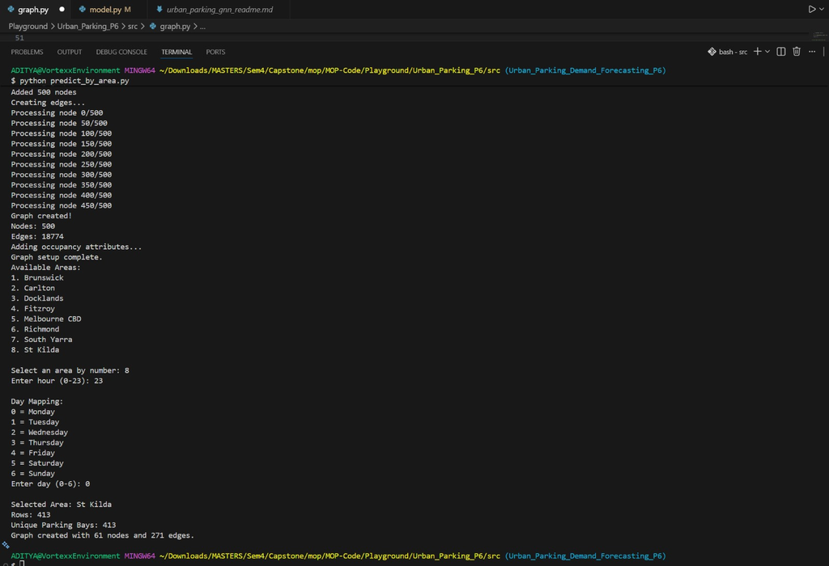

## **Screenshot of the final interactive graph**

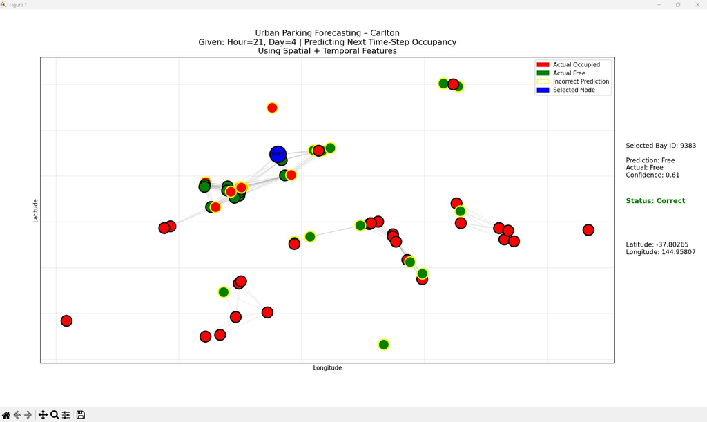

**Screenshot of the GitHub repository structure**

[figure not shown]